# Class and QWL analysis

Jerzy Eisenberg-Guyot

February, 2021

**To-do**

- Make functions more efficient

**Questions**

- Need to figure out what to do with “NH other” category, which has small counts. Should we exclude them in interaction analyses, given small cell sizes (n=283 in unimputed data) and rarity of outcomes? Would make plots simpler too.
- Does the grouping and labelling of variables make sense?
- For the analyses within the working class, which interactions should we present?

**Comments**

- Excluded “knowschd” because it was only asked in two years, so cell sizes were really small, and respondents didn’t answer using a Likert scale like they did with the others.

**Codebook for non-self-explanatory variables**

- Class variables:
  - explained in 2020 IJHS paper (doi: 10.1177/0020731419886194)
- Health variables:
  - srh_bin: poor/fair vs good/vgood/excellent self-rated health
  - depress: whether respondent has ever been diagnosed by a healthcare professional with depression
  - mntlhlth: days of poor mental health in past 30 days
- QWL variables:
  - wrktype : Work arrangement at main job
  - yearsjob : Time at current job
  - waypaid : How paid in main job
  - wrksched : Usual work schedule
  - moredays : Days per month r work extra hours
  - mustwork : Mandatory to work extra hours
  - chngtme : How often r allowed change schedule
  - wrkhome : How often r works at home
  - whywkhme : Usual reason r work at home
  - famwkoff : How hard to take time off
  - wkvsfam : How often job interferes fam life
  - famvswk : How often fam life interfere job
  - hrsrelax : Hours per day r have to relax
  - secondwk : R has job other than main
  - learnnew : Job requires r to learn new things
  - workfast : Job requires r to work fast
  - workdiff : R does numerous things on job
  - lotofsay : R has lot of say in job
  - wktopsat : Satisfaction comes from work
  - overwork : R has too much work to do well
  - knowwhat : R knows what’s expected on job
  - myskills : Job allows r use of skills
  - respect : R treated with respect at work
  - trustman : R trust management at work
  - safetywk : Worker safety priority at work
  - safefrst : No shortcuts on worker safety
  - teamsafe : Mgt and employees work together re safety
  - safehlth : Safety and health condition good at work
  - proudemp : R proud to work for employer
  - prodctiv : Work conditions allow productivity
  - wksmooth : Workplace runs in smooth manner
  - trdunion : Workers need strong unions
  - partteam : R work as part of a team
  - wkdecide : How often r take part in decisions
  - setthngs : How often r set way things done
  - toofewwk : How often not enough staff
  - promteok : Rs chances for promotion good
  - opdevel : Opportunity to develop my abilities
  - hlpequip : Enough help and equip to ge the job done
  - haveinfo : Enough info to get the job done
  - wkfreedm : A lot of freedom to decide how to do job
  - fringeok : Fringe benefits are good
  - supcares : Supervisor concerned about welfare
  - condemnd : R free from conflicting demands
  - promtefr : Promotions are handled fairly
  - cowrkint : Coworkers take a personal interest in r
  - jobsecok : The job security is good
  - suphelp : Supervisor helpful to r in getting job done
  - wrktime : R has enough time to get the job done
  - cowrkhlp : Coworkers can be relied on when r needs help
  - trainops : R have the training opportunities
  - manvsemp : Relations bw management and employees
  - hvylift : R do repeated lifting
  - handmove : R perform forceful hand movements
  - wkpraise : R is likely to be praised by supervisor
  - wkbonus : R is likely to get a bonus or pay increase
  - fairearn : How fair is what r earn on the job
  - rincblls : Income alone is enough
  - laidoff : R was laid off main job last year
  - jobfind1 : How easy for r to find a same job
  - trynewjb : How likely r make effort for new job next year
  - wkageism : R feels discriminated because of age
  - wkracism : R feels discriminated because of race
  - wksexism : R feels discriminated because of gender
  - wkharsex : R sexually harassed on the job last 12 months
  - wkharoth : R threatened on the job last 12 months
  - health1 : Rs health in general
  - physhlth : Days of poor physical health past 30 days
  - mntlhlth : Days of poor mental health past 30 days
  - hlthdays : Days of activity limitation past 30 days
  - usedup : How often during past month r felt used up
  - backpain : R had back pain in the past 12 months
  - painarms : R had pain in the arms in the past 12 months
  - hurtatwk : Number of injuries on the job past 12 months
  - spvtrfair : Supervisor is fair
  - strredpg : Access to stress management
  - phyeffrt : Rate physical effort
  - slpprblm : Trouble sleeping last 12 months
  - satjob1 : Job satisfaction in general
  - knowschd : How far in advance know work schedule
  - usetech : Percentage of time use tech
  - stress12 : Stress management program last 12 months
  - hyperten : Told have hypertension or high blood pressure
  - arthrtis : Told have arthritis or rheumatism
  - diabetes : Told have diabetes
  - depress : Told have depression
  - weight : R weighs how much
  - height : R is how tall
  - ntwkhard : Past week not work hard enough
  - misswork : Miss work for health past 30 days

```r
library(readstata13)
library(foreign)
library(tidyr)
library(dplyr)
library(survival)
library(knitr)
library(ggplot2)
library(kableExtra)
library(survey)
library(tableone)
library(RColorBrewer)
library(survey)
library(VIM)
library(mice)
library(parallel)
library(mitools)
library(viridis)
library(survminer)
library(gridExtra)
library(stringr)
library(rms)
library(patchwork)
library(spatstat)
library(purrr)

#########load data, which is a subsetted version of the GSS cumulative file available at the GSS website that I converted from .dta to .csv using Stata
#####
#
#drop survey-ballot d, which was a ballot in 2006 that lacked responses to QWL variables
#remove those who were not employed, as only employed respondents were asked the QWL variables - also remove those with NA wrkstat (n=9), since they weren't asked the QWL variables
#remove ballot b in 2002, as class variables weren't asked of that ballot in that year
#remove 421 respondents who still have IAP in 2006 and 2014 for QWL variables, even after making appropriate sample restrictions - according to GSS helpdesk, they weren't administered the questions/didn't complete the survey ('breakoffs')
read.csv('GSS_02_06_10_14_18.csv') %>%
  filter(ballot != "ballot d") %>%
  filter(wrkstat=="working fulltime" | wrkstat=="working parttime" | wrkstat=="temp not working") %>%
  filter(!(year==2002 & ballot=="ballot b")) %>%
  mutate_all(funs(ifelse(.=="DK" | .=="NO ANSWER" | .=="DONT KNOW" | .=="Not asked" | .=="IAP,DK,NA,uncodeable" | .==".a", NA, .))) %>%
  filter(is.na(respect) | respect!="IAP") -> dat #removing those with IAP for respect is sufficient since IAPs are the same across other QWL variables

#########code new variables and make sure other variables coded correctly and will be treated appropriately by MICE (e.g., no character vars)
######
#

dat %>%
  mutate(educ=factor(ifelse(degree == "bachelor" | degree == "graduate", "College +",
                              ifelse(degree== "high school", "HS",
                                     ifelse(degree == "junior college", "JuCo",
                                            ifelse(degree == "lt high school", "<HS", NA)))),
                       levels=c("<HS", "HS", "JuCo", "College +")),
         hispanic_bin=ifelse(hispanic=="not hispanic", 0, 1),
         race_h=factor(ifelse(race=="white" & hispanic_bin==0, "NH white",
                              ifelse(race=="black" & hispanic_bin==0, "NH Black",
                                     ifelse(race=="other" & hispanic_bin==0, "NH other",
                                            ifelse(hispanic_bin==1, "Hispanic", NA)))), levels=c("NH white", "NH Black", "NH other", "Hispanic")),
         age=ifelse(age=="89 or older", 89, as.numeric(as.character(age))),
         mntlhlth=as.numeric(as.character(mntlhlth)),
         physhlth=as.numeric(as.character(physhlth)),
         hlthdays=as.numeric(as.character(hlthdays)),
         moredays=as.numeric(as.character(moredays)),
         region = factor(ifelse(region == "new england" | region == "middle atlantic", "Northeast",
                                   ifelse(region == "e. sou. central" | region == "south atlantic" | region == "w. sou. central", "South",
                                          ifelse(region == "e. nor. central" | region == "w. nor. central", "Midwest", "West")))),
         marital_tri=as.factor(ifelse(marital=="married", "married",
                            ifelse(marital=="never married", "never married",
                                   ifelse(marital=="widowed" | marital=="divorced" | marital=="separated", "wid/div/sep", marital)))),
         srh_bin=as.factor(ifelse(health1 == "fair" | health1 == "poor", "poor/fair", "good/vgood/exc")),
         race_poc=as.factor(ifelse(race=="white", "white",
                         ifelse(race=="black" | race=="other", "poc", NA))),
         race=factor(race, levels=c("white", "black", "other")),
         sex=as.factor(sex),
         disc_haras_bin=ifelse(wkageism=="yes" | wkracism=="yes" | wksexism=="yes" | wkharsex=="yes" | wkharoth=="yes", 1, 0),
         disc_haras_bin_unimp=disc_haras_bin, #make duplicated version of each variable for which we wont impute data for so that we can use it in outcome regression
         respect_bin=ifelse(respect=="disagree" | respect=="strongly disagree", 1, 0),
         respect_bin_unimp=respect_bin,
         trustman_bin=ifelse(trustman=="disagree" | trustman=="strongly disagree", 1, 0),
         trustman_bin_unimp=trustman_bin,
         manvsemp_bin=ifelse(manvsemp=="quite bad" | manvsemp=="very bad", 1, 0),
         manvsemp_bin_unimp=manvsemp_bin,
         suphelp_bin=ifelse(suphelp=="not too true" | suphelp=="not at all true", 1, 0),
         suphelp_bin_unimp=suphelp_bin,
         supcares_bin=ifelse(supcares=="not too true" | supcares=="not at all true", 1, 0),
         supcares_bin_unimp=supcares_bin,
         wkfreedm_bin=ifelse(wkfreedm=="not too true" | wkfreedm=="not at all true", 1, 0),
         wkfreedm_bin_unimp=wkfreedm_bin,
         wkdecide_bin=ifelse(wkdecide=="rarely" | wkdecide=="never", 1, 0),
         wkdecide_bin_unimp=wkdecide_bin,
         safehlth_bin=ifelse(safehlth=="disagree" | safehlth=="strongly disagree", 1, 0),
         safehlth_bin_unimp=safehlth_bin,
         safetywk_bin=ifelse(safetywk=="disagree" | safetywk=="strongly disagree", 1, 0),
         safetywk_bin_unimp=safetywk_bin,
         safefrst_bin=ifelse(safefrst=="disagree" | safefrst=="strongly disagree", 1, 0),
         safefrst_bin_unimp=safefrst_bin,
         mustwork_bin=ifelse(mustwork=="yes", 1, 0),
         mustwork_bin_unimp=mustwork_bin,
         famwkoff_bin=ifelse(famwkoff=="somewhat hard" | famwkoff=="very hard", 1, 0),
         famwkoff_bin_unimp=famwkoff_bin,
         wkvsfam_bin=ifelse(wkvsfam=="often" | wkvsfam=="sometimes", 1, 0),
         wkvsfam_bin_unimp=wkvsfam_bin,
         workfast_bin=ifelse(workfast=="agree" | workfast=="strongly agree", 1, 0),
         workfast_bin_unimp=workfast_bin,
         workdiff_bin=ifelse(workdiff=="disagree" | workdiff=="strongly disagree", 1, 0),
         workdiff_bin_unimp=workdiff_bin,
         overwork_bin=ifelse(overwork=="agree" | overwork=="strongly agree", 1, 0),
         overwork_bin_unimp=overwork_bin,
         wkpraise_bin=ifelse(wkpraise=="no", 1, 0),
         wkpraise_bin_unimp=wkpraise_bin,
         opdevel_bin=ifelse(opdevel=="not too true" | opdevel=="not at all true", 1, 0),
         opdevel_bin_unimp=opdevel_bin,
         wrktime_bin=ifelse(wrktime=="not too true" | wrktime=="not at all true", 1, 0),
         wrktime_bin_unimp=wrktime_bin,
         learnnew_bin=ifelse(learnnew=="disagree" | learnnew=="strongly disagree", 1, 0),
         learnnew_bin_unimp=learnnew_bin,
         condemnd_bin=ifelse(condemnd=="not too true" | condemnd=="not at all true", 1, 0),
         condemnd_bin_unimp=condemnd_bin,
         hlpequip_bin=ifelse(hlpequip=="not too true" | hlpequip=="not at all true", 1, 0),
         hlpequip_bin_unimp=hlpequip_bin,
         cowrkhlp_bin=ifelse(cowrkhlp=="not too true" | cowrkhlp=="not at all true", 1, 0),
         cowrkhlp_bin_unimp=cowrkhlp_bin,
         knowschd_bin=ifelse(knowschd=="not too true" | knowschd=="not at all true", 1, 0),
         knowschd_bin_unimp=knowschd_bin,
         satjob1_bin=ifelse(satjob1=="not at all satisifed" | satjob1=="not too satisfied", 1, 0),
         satjob1_bin_unimp=satjob1_bin,
         rincblls_bin=ifelse(rincblls=="no", 1, 0),
         rincblls_bin_unimp=rincblls_bin,
         fringeok_bin=ifelse(fringeok=="not too true" | fringeok=="not at all true", 1, 0),
         fringeok_bin_unimp=fringeok_bin,
         chngtme_bin=ifelse(chngtme=="IAP", NA, #chngtme not asked in 2018
                            ifelse(chngtme=="never" | chngtme=="rarely", 1, 0)),
         chngtme_bin_unimp=chngtme_bin,
         income=as.numeric(as.character(coninc)) * 251.1 / 172.2, #adjust income to 2018 dollars from 2000 dollars
         prestg10=as.numeric(prestg10),
         #we could also create the class variable using numemps (number of employees employed by the self-employed), but it's not available in 2002
         class=factor(ifelse((wksup == "yes" & wrkslf == "self-employed") | (wksup == "yes" & wrkslf == "someone else" & occ10 == "chief executives"), "Capitalists",
                              ifelse((wksup == "no" & wrkslf == "self-employed") | (wksup == "no" & wrkslf == "someone else" & occ10 == "chief executives"), "Petit bourgeoisie",
                                                 ifelse(wksup == "yes" & wrkslf == "someone else" & occ10 != "chief executives", "Managers",
                                                        ifelse(wksup == "no" & wrkslf ==  "someone else" & occ10 != "chief executives", "Workers", NA)))),
                                   levels=c("Workers", "Managers", "Petit bourgeoisie", "Capitalists")),
         race_h_gender=factor(ifelse(race_h=="NH white" & sex=="male", "NH white men",
                                   ifelse(race_h=="NH white" & sex=="female", "NH white women",
                                          ifelse(race_h=="NH Black" & sex=="male", "NH Black men",
                                                 ifelse(race_h=="NH Black" & sex=="female", "NH Black women",
                                                        ifelse(race_h=="NH other" & sex=="male", "NH other men",
                                                               ifelse(race_h=="NH other" & sex=="female", "NH other women",
                                                                      ifelse(race_h=="Hispanic" & sex=="male", "Hispanic men",
                                                                             ifelse(race_h=="Hispanic" & sex=="female", "Hispanic women", NA)))))))),
                            levels=c("NH white men", "NH white women", "NH Black men", "NH Black women", "NH other men", "NH other women", "Hispanic men", "Hispanic women"))) -> dat
```

# Confirming that class, race, and gender variables are coded correctly

```r
#class variable
kable(table(dat$class, dat$wrkslf, dat$wksup, dat$occ10=="chief executives"), caption="Class by self employed by supervisor by chief executive", col.names=c("Class", "Self-employed", "Supervisor", "Chief executive", "Count")) %>%
  kable_styling("striped") %>%
  scroll_box(width = "100%", height = "250px")
```

Class by self employed by supervisor by chief executive

| Class | Self-employed | Supervisor | Chief executive | Count |
| --- | --- | --- | --- | --- |
| Workers | self-employed | no | FALSE | 0 |
| Managers | self-employed | no | FALSE | 0 |
| Petit bourgeoisie | self-employed | no | FALSE | 523 |
| Capitalists | self-employed | no | FALSE | 0 |
| Workers | someone else | no | FALSE | 3737 |
| Managers | someone else | no | FALSE | 0 |
| Petit bourgeoisie | someone else | no | FALSE | 0 |
| Capitalists | someone else | no | FALSE | 0 |
| Workers | self-employed | yes | FALSE | 0 |
| Managers | self-employed | yes | FALSE | 0 |
| Petit bourgeoisie | self-employed | yes | FALSE | 0 |
| Capitalists | self-employed | yes | FALSE | 358 |
| Workers | someone else | yes | FALSE | 0 |
| Managers | someone else | yes | FALSE | 2084 |
| Petit bourgeoisie | someone else | yes | FALSE | 0 |
| Capitalists | someone else | yes | FALSE | 0 |
| Workers | self-employed | no | TRUE | 0 |
| Managers | self-employed | no | TRUE | 0 |
| Petit bourgeoisie | self-employed | no | TRUE | 3 |
| Capitalists | self-employed | no | TRUE | 0 |
| Workers | someone else | no | TRUE | 0 |
| Managers | someone else | no | TRUE | 0 |
| Petit bourgeoisie | someone else | no | TRUE | 3 |
| Capitalists | someone else | no | TRUE | 0 |
| Workers | self-employed | yes | TRUE | 0 |
| Managers | self-employed | yes | TRUE | 0 |
| Petit bourgeoisie | self-employed | yes | TRUE | 0 |
| Capitalists | self-employed | yes | TRUE | 11 |
| Workers | someone else | yes | TRUE | 0 |
| Managers | someone else | yes | TRUE | 0 |
| Petit bourgeoisie | someone else | yes | TRUE | 0 |
| Capitalists | someone else | yes | TRUE | 27 |

```r
#race-gender variable
kable(table(dat$race_h_gender, dat$race_h, dat$sex), caption="Race-gender by race and gender", col.names=c("Race-gender", "Race", "Gender", "Count")) %>%
  kable_styling("striped") %>%
  scroll_box(width = "100%", height = "250px")
```

Race-gender by race and gender

| Race-gender | Race | Gender | Count |
| --- | --- | --- | --- |
| NH white men | NH white | female | 0 |
| NH white women | NH white | female | 2356 |
| NH Black men | NH white | female | 0 |
| NH Black women | NH white | female | 0 |
| NH other men | NH white | female | 0 |
| NH other women | NH white | female | 0 |
| Hispanic men | NH white | female | 0 |
| Hispanic women | NH white | female | 0 |
| NH white men | NH Black | female | 0 |
| NH white women | NH Black | female | 0 |
| NH Black men | NH Black | female | 0 |
| NH Black women | NH Black | female | 620 |
| NH other men | NH Black | female | 0 |
| NH other women | NH Black | female | 0 |
| Hispanic men | NH Black | female | 0 |
| Hispanic women | NH Black | female | 0 |
| NH white men | NH other | female | 0 |
| NH white women | NH other | female | 0 |
| NH Black men | NH other | female | 0 |
| NH Black women | NH other | female | 0 |
| NH other men | NH other | female | 0 |
| NH other women | NH other | female | 143 |
| Hispanic men | NH other | female | 0 |
| Hispanic women | NH other | female | 0 |
| NH white men | Hispanic | female | 0 |
| NH white women | Hispanic | female | 0 |
| NH Black men | Hispanic | female | 0 |
| NH Black women | Hispanic | female | 0 |
| NH other men | Hispanic | female | 0 |
| NH other women | Hispanic | female | 0 |
| Hispanic men | Hispanic | female | 0 |
| Hispanic women | Hispanic | female | 399 |
| NH white men | NH white | male | 2339 |
| NH white women | NH white | male | 0 |
| NH Black men | NH white | male | 0 |
| NH Black women | NH white | male | 0 |
| NH other men | NH white | male | 0 |
| NH other women | NH white | male | 0 |
| Hispanic men | NH white | male | 0 |
| Hispanic women | NH white | male | 0 |
| NH white men | NH Black | male | 0 |
| NH white women | NH Black | male | 0 |
| NH Black men | NH Black | male | 381 |
| NH Black women | NH Black | male | 0 |
| NH other men | NH Black | male | 0 |
| NH other women | NH Black | male | 0 |
| Hispanic men | NH Black | male | 0 |
| Hispanic women | NH Black | male | 0 |
| NH white men | NH other | male | 0 |
| NH white women | NH other | male | 0 |
| NH Black men | NH other | male | 0 |
| NH Black women | NH other | male | 0 |
| NH other men | NH other | male | 140 |
| NH other women | NH other | male | 0 |
| Hispanic men | NH other | male | 0 |
| Hispanic women | NH other | male | 0 |
| NH white men | Hispanic | male | 0 |
| NH white women | Hispanic | male | 0 |
| NH Black men | Hispanic | male | 0 |
| NH Black women | Hispanic | male | 0 |
| NH other men | Hispanic | male | 0 |
| NH other women | Hispanic | male | 0 |
| Hispanic men | Hispanic | male | 414 |
| Hispanic women | Hispanic | male | 0 |

# Handling missing data

## Missingness patterns

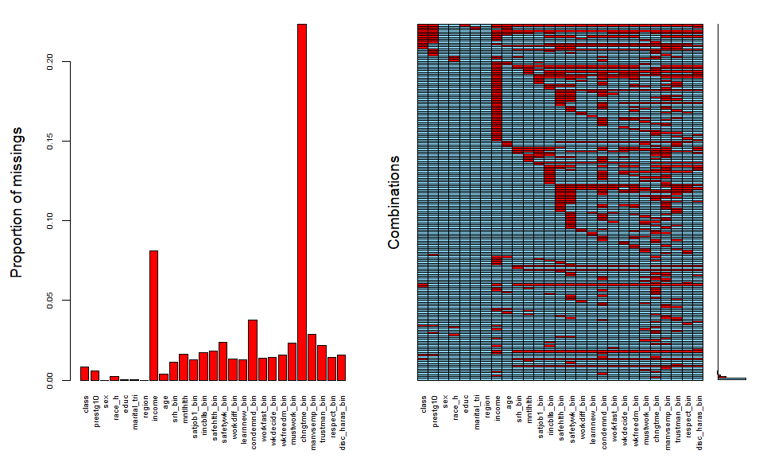

```r
aggr(dat[,c("class", "prestg10", 'sex', 'race_h', 'educ', 'marital_tri', 'region', 'income', 'age', "srh_bin", "mntlhlth", "satjob1_bin", "rincblls_bin", "safehlth_bin", "safetywk_bin", "workdiff_bin", "learnnew_bin", "condemnd_bin", "workfast_bin", "wkdecide_bin", "wkfreedm_bin", "mustwork_bin", "chngtme_bin", "manvsemp_bin", "trustman_bin", "respect_bin", "disc_haras_bin")], cex.axis = 0.6, numbers=FALSE, prop=TRUE)
```

## Multiple imputation

```r
#make imputation dataset. note that we're not using chngtme_bin as an imputation variable since it wasn't asked at all in 2018; correlation with other variables should mitigate bias towards null
dat_mice <- dat[,c('vpsu', 'vstrat', 'wtssall', 'year', 'age', 'sex', 'race_h', 'educ', 'region', 'marital_tri', 'income', "prestg10", "class", "race_h_gender", "srh_bin", "mntlhlth", "satjob1_bin", "rincblls_bin", "safehlth_bin", "safetywk_bin", "workdiff_bin", "learnnew_bin", "condemnd_bin", "workfast_bin", "wkdecide_bin", "wkfreedm_bin", "mustwork_bin", "chngtme_bin", "manvsemp_bin", "trustman_bin", "respect_bin", "disc_haras_bin", "satjob1_bin_unimp", "rincblls_bin_unimp", "safehlth_bin_unimp", "safetywk_bin_unimp", "workdiff_bin_unimp", "learnnew_bin_unimp", "condemnd_bin_unimp", "workfast_bin_unimp", "wkdecide_bin_unimp", "wkfreedm_bin_unimp", "mustwork_bin_unimp", "chngtme_bin_unimp", "manvsemp_bin_unimp", "trustman_bin_unimp", "respect_bin_unimp", "disc_haras_bin_unimp")]

#this creates an empty imputation object that you can manipulate and set options
initialize <- mice(dat_mice, max=0, print=FALSE)

#this creates an object that will contain the imputation method for each variable. let mice choose defaults based on variable class
method <- initialize$method

#this code tells mice not to impute these variables: not imputing variables with complete data or the unimputed versions of the outcome variables; don't impute chngtme_bin either, since it wasn't asked in 2018
method[c("vpsu", 'vstrat', 'wtssall', "year", "sex", "region", "satjob1_bin_unimp", "rincblls_bin_unimp", "safehlth_bin_unimp", "safetywk_bin_unimp", "workdiff_bin_unimp", "learnnew_bin_unimp", "condemnd_bin_unimp", "workfast_bin_unimp", "wkdecide_bin_unimp", "wkfreedm_bin_unimp", "mustwork_bin_unimp", "chngtme_bin", "chngtme_bin_unimp", "manvsemp_bin_unimp", "trustman_bin_unimp", "respect_bin_unimp", "disc_haras_bin_unimp")] <- ""

#use logistic models for imputed versions of outcome variables: default otherwise is pmm since I didn't code them as factor variables above
method[c("satjob1_bin", "rincblls_bin", "safehlth_bin", "safetywk_bin", "workdiff_bin", "learnnew_bin", "condemnd_bin", "workfast_bin", "wkdecide_bin", "wkfreedm_bin", "mustwork_bin", "manvsemp_bin", "trustman_bin", "respect_bin", "disc_haras_bin")] <- "logreg"

#passive imputation of variables that are perfect combos of other variables
method['race_h_gender'] <- "~ifelse(race_h=='NH white' & sex=='male', 'NH white men',
                                    ifelse(race_h=='NH white' & sex=='female', 'NH white women',
                                          ifelse(race_h=='NH Black' & sex=='male', 'NH Black men',
                                                 ifelse(race_h=='NH Black' & sex=='female', 'NH Black women',
                                                        ifelse(race_h=='NH other' & sex=='male', 'NH other men',
                                                               ifelse(race_h=='NH other' & sex=='female', 'NH other women',
                                                                      ifelse(race_h=='Hispanic' & sex=='male', 'Hispanic men',
                                                                                   ifelse(race_h=='Hispanic' & sex=='female', 'Hispanic women', NA))))))))"

#this creates an object that will indicate which variables we actually want to include in predicting missing variables.
prediction <- initialize$predictorMatrix

#don't use interacted race-gender variable as predictor since it's collinear with uninteracted versions of those variables; also don't use vstrat, since it has so many levels that models dont fit; don't use duplicated versions of dependent variables; don't use chngtme_bin, since it wasn't asked in 2018
prediction[,c("race_h_gender", 'vstrat', "satjob1_bin_unimp", "rincblls_bin_unimp", "safehlth_bin_unimp", "safetywk_bin_unimp", "workdiff_bin_unimp", "learnnew_bin_unimp", "condemnd_bin_unimp", "workfast_bin_unimp", "wkdecide_bin_unimp", "wkfreedm_bin_unimp", "mustwork_bin_unimp", "chngtme_bin", "chngtme_bin_unimp", "manvsemp_bin_unimp", "trustman_bin_unimp", "respect_bin_unimp", "disc_haras_bin_unimp")] <- 0

#run MICE in parallel (4 cores * 5 imputations per core = 20 imputed datasets)
imp_merged <- parlmice(dat_mice, n.core=4, n.imp.core=5, meth=method, pred=prediction, maxit = 25, cluster.seed=9956)

#put data into usable format for survey package
imp.list <- lapply(1:20, function(x) mice::complete(imp_merged, x))
dat_mi <- imputationList(imp.list)
```

# Survey set the data

```r
#center data for the single-PSU stratum at the sample grand mean rather than the stratum mean (conservative)
options(survey.lonely.psu="adjust")

#make imputed survey design object
svy_dat_mi <- svydesign(ids = ~ vpsu,
                 strata = ~ vstrat,
                 weights = ~ wtssall,
                 nest=TRUE,
                 data=dat_mi)

#survey-set unimputed data for descriptives
svy_dat <- svydesign(ids = ~ vpsu,
                     strata = ~ vstrat,
                     weights = ~ wtssall,
                     nest=TRUE,
                     data=dat)
```

# Survey-weighted, unimputed descriptives

## Demographics and health stratifed by class

```r
#vars of interest
vars <- c('sex', 'race_h', 'educ', 'marital_tri', 'region', 'income', 'age', "srh_bin", "mntlhlth")
nonorm <- c('income', 'age')

x <- svyCreateTableOne(data = svy_dat, vars = vars, strata='class')
x <- print(x, printToggle=FALSE, noSpaces=TRUE, nonnormal=nonorm)
kable(x[,1:4]) %>%
  kable_styling(c("striped", "condensed"))
```

|  | Workers | Managers | Petit bourgeoisie | Capitalists |
| --- | --- | --- | --- | --- |
| n | 3821.8 | 2128.6 | 544.2 | 423.8 |
| sex = male (%) | 1703.1 (44.6) | 1097.2 (51.5) | 278.4 (51.2) | 324.9 (76.7) |
| race_h (%) |  |  |  |  |
| NH white | 2521.9 (66.1) | 1514.9 (71.2) | 392.8 (72.3) | 337.6 (79.9) |
| NH Black | 599.7 (15.7) | 252.9 (11.9) | 40.4 (7.4) | 23.4 (5.5) |
| NH other | 145.0 (3.8) | 108.7 (5.1) | 39.2 (7.2) | 29.4 (7.0) |
| Hispanic | 547.5 (14.4) | 249.9 (11.8) | 71.0 (13.1) | 32.0 (7.6) |
| educ (%) |  |  |  |  |
| <HS | 359.4 (9.4) | 158.1 (7.4) | 65.0 (11.9) | 33.4 (7.9) |
| HS | 2111.2 (55.2) | 927.3 (43.6) | 259.7 (47.7) | 170.7 (40.3) |
| JuCo | 345.7 (9.0) | 227.7 (10.7) | 50.0 (9.2) | 31.1 (7.3) |
| College + | 1005.5 (26.3) | 815.5 (38.3) | 169.5 (31.1) | 188.7 (44.5) |
| marital_tri (%) |  |  |  |  |
| married | 1950.2 (51.0) | 1190.8 (55.9) | 327.5 (60.2) | 301.5 (71.1) |
| never married | 1192.5 (31.2) | 565.9 (26.6) | 106.1 (19.5) | 41.6 (9.8) |
| wid/div/sep | 679.1 (17.8) | 371.8 (17.5) | 110.6 (20.3) | 80.7 (19.0) |
| region (%) |  |  |  |  |
| Midwest | 932.2 (24.4) | 475.6 (22.3) | 99.9 (18.4) | 87.7 (20.7) |
| Northeast | 630.1 (16.5) | 395.9 (18.6) | 87.4 (16.1) | 57.2 (13.5) |
| South | 1485.9 (38.9) | 745.6 (35.0) | 197.7 (36.3) | 150.2 (35.4) |
| West | 773.6 (20.2) | 511.5 (24.0) | 159.1 (29.2) | 128.6 (30.3) |
| income (median [IQR]) | 63838.02 [35022.03, 102218.99] | 84330.67 [48492.05, 128628.24] | 63838.02 [32196.43, 122662.79] | 122662.79 [69724.29, 230688.05] |
| age (median [IQR]) | 40.00 [29.00, 51.00] | 42.00 [31.00, 51.00] | 49.00 [37.00, 58.00] | 50.00 [40.00, 58.00] |
| srh_bin = poor/fair (%) | 579.3 (15.2) | 271.1 (12.9) | 83.4 (15.6) | 43.4 (10.4) |
| mntlhlth (mean (SD)) | 3.55 (7.14) | 3.34 (6.83) | 2.55 (6.13) | 2.98 (6.99) |

## Select QWL variables stratified by class

Unadjusted prevalence of bad category of each binary QWL variable among each class.

```r
#vars of interest
qwl_vars <- c("satjob1_bin", "rincblls_bin", "safehlth_bin", "safetywk_bin", "workdiff_bin", "learnnew_bin", "condemnd_bin", "workfast_bin", "wkdecide_bin", "wkfreedm_bin", "mustwork_bin", "chngtme_bin", "manvsemp_bin", "trustman_bin", "respect_bin", "disc_haras_bin")

x <- svyCreateTableOne(data = svy_dat, vars = qwl_vars, factorVars=qwl_vars, strata='class')
x <- print(x, printToggle=FALSE, noSpaces=TRUE)
kable(x[,1:4]) %>%
  kable_styling(c("striped", "condensed"))
```

|  | Workers | Managers | Petit bourgeoisie | Capitalists |
| --- | --- | --- | --- | --- |
| n | 3821.8 | 2128.6 | 544.2 | 423.8 |
| satjob1_bin = 1 (%) | 315.7 (8.3) | 149.1 (7.1) | 19.6 (3.7) | 10.6 (2.5) |
| rincblls_bin = 1 (%) | 2289.9 (60.5) | 1011.8 (48.2) | 289.4 (55.1) | 121.4 (29.5) |
| safehlth_bin = 1 (%) | 258.2 (6.8) | 110.3 (5.2) | 19.7 (3.8) | 17.0 (4.2) |
| safetywk_bin = 1 (%) | 362.6 (9.6) | 165.5 (7.9) | 17.0 (3.4) | 15.1 (3.7) |
| workdiff_bin = 1 (%) | 529.4 (13.9) | 114.2 (5.4) | 62.2 (11.7) | 20.9 (5.0) |
| learnnew_bin = 1 (%) | 650.0 (17.1) | 169.1 (8.0) | 68.7 (12.9) | 16.5 (4.0) |
| condemnd_bin = 1 (%) | 904.3 (24.4) | 639.7 (31.0) | 87.4 (17.5) | 118.8 (29.4) |
| workfast_bin = 1 (%) | 2450.7 (64.6) | 1558.0 (74.1) | 275.8 (51.8) | 307.2 (74.1) |
| wkdecide_bin = 1 (%) | 1081.6 (28.5) | 231.1 (11.0) | 211.6 (40.2) | 62.7 (15.4) |
| wkfreedm_bin = 1 (%) | 613.8 (16.2) | 201.3 (9.6) | 19.5 (3.7) | 6.4 (1.6) |
| mustwork_bin = 1 (%) | 926.2 (24.7) | 633.4 (30.2) | 123.8 (23.7) | 136.5 (33.8) |
| chngtme_bin = 1 (%) | 1673.2 (56.6) | 705.9 (42.2) | 53.4 (12.7) | 50.3 (15.2) |
| manvsemp_bin = 1 (%) | 318.6 (8.4) | 138.5 (6.6) | 10.2 (2.3) | 7.6 (1.9) |
| trustman_bin = 1 (%) | 833.9 (22.0) | 398.0 (19.0) | 26.4 (5.1) | 18.9 (4.7) |
| respect_bin = 1 (%) | 334.9 (8.8) | 131.3 (6.2) | 22.4 (4.2) | 11.6 (2.8) |
| disc_haras_bin = 1 (%) | 789.4 (20.8) | 499.3 (23.8) | 72.6 (13.8) | 67.9 (16.6) |

# Survey-weighted associations between select QWL variables and class from Poisson regressions

Restricted to intrinsically relational variables with potentially interesting differences across classes or races.

## Functions

```r
#regression function
mysvy <- function(dat, columns, adjvars, ...){
  model <- lapply(as.list(columns), function(x){
    with(dat, svyglm(as.formula(paste0(names(dat$designs[[1]]$variables)[x], adjvars)), family=poisson(), ...))
  })
  return(model)
}

#regression matrix function
matrix_func <- function(nums, coefs, cols){
  regs_less = NULL
  for(i in 1:nums){
    exp(summary(MIcombine(less_adj[[i]]))[2:coefs,c(1,3,4)]) -> bind
    rbind(regs_less, cbind(bind, names(svy_dat_mi$designs[[1]]$variables)[cols][i])) -> regs_less
  }
  names(regs_less) <- c("PR", "Lower", "Upper", "Var")
  return(regs_less)
}

#format matrix function
formatted <- function(classvec, rows, qwlvec, dummy, facvec){
  as.data.frame(regs_less) %>%
    mutate(Class=rep(classvec, rows)) %>%
    bind_rows(data.frame(Var=qwlvec,
                         Class=rep(dummy, rows), PR=rep(1, rows), Lower=rep(NA, rows), Upper=rep(NA, rows))) %>% #worker dummy row
    mutate(Class=factor(Class, levels=facvec),
           Var=factor(Var, levels=qwlvec),
           Cat=ifelse(Var=="satjob1_bin_unimp" | Var=="rincblls_bin_unimp" | Var=="safehlth_bin_unimp" | Var=="safetywk_bin_unimp", "Rewards/hazards",
                      ifelse(Var=="learnnew_bin_unimp" | Var=="workdiff_bin_unimp" | Var == "workfast_bin_unimp" | Var=="condemnd_bin_unimp", "Labor process",
                             ifelse(Var=="wkdecide_bin_unimp" | Var=="wkfreedm_bin_unimp" | Var == "mustwork_bin_unimp" | Var=="chngtme_bin_unimp", "Autonomy",
                                    ifelse(Var=="manvsemp_bin_unimp" | Var=="trustman_bin_unimp" | Var == "respect_bin_unimp" | Var=="disc_haras_bin_unimp", "Conflict", NA))))) -> binded
  return(binded)
}

#facet labeller function
facet_names <- list(
  "satjob1_bin_unimp"="Dissatisfied with job",
  "rincblls_bin_unimp"="Income doesn't pay bills",
  "safehlth_bin_unimp"="Poor safety conditions",
  "safetywk_bin_unimp"="Safety not a priority",
  "workdiff_bin_unimp"="Repetitive tasks",
  "learnnew_bin_unimp"="Don't learn new things",
  "condemnd_bin_unimp"="Face conflicting demands",
  "workfast_bin_unimp"="Need to work fast",
  "wkdecide_bin_unimp"="Don't make decisions",
  "wkfreedm_bin_unimp"="No freedom on job",
  "mustwork_bin_unimp"="Mandatory extra hours",
  "chngtme_bin_unimp"="Can't change schedule",
  "manvsemp_bin_unimp"="Worker-manager conflict",
  "trustman_bin_unimp"="Don't trust management",
  "respect_bin_unimp"="Not treated with respect",
  "disc_haras_unimp"="Face discrim. & harass."
)

facet_labeller <- function(variable,value){
  return(facet_names[value])
}

#plot function
plotted <- function(rows, xaxis, limitsvec, breaksvec, cols, shapes){
  xaxis <- enquo(xaxis)
  ggplot(binded[rows,], aes(x=!!xaxis, y=PR, ymin=Lower, ymax=Upper, shape=!!xaxis, color=!!xaxis)) +
    geom_hline(yintercept=1, lty=1, col='darkgrey') +
    geom_errorbar(width=0.5) +
    geom_point(size=2) +
    facet_wrap(~Var, ncol=1, labeller=facet_labeller) +
    scale_y_continuous(trans="log", limits=limitsvec, breaks=breaksvec, labels=scales::number_format(accuracy=0.01)) +
    theme_light() +
    scale_color_manual(values=cols) +
    scale_shape_manual(values=shapes) +
    xlab('') +
    ylab("Prevalence ratio") +
    ggtitle(binded$Cat[rows]) +
    theme(strip.background = element_rect(fill=NA, color='grey'), strip.text = element_text(colour = "black"),
          legend.position='none', axis.title.x = element_blank(), axis.text.x = element_blank(),
          axis.ticks.x=element_blank(), plot.title = element_text(hjust = 0.5))
}

#legend function
legends <- function(rows, xaxis, cols, shapes, nrow=1){
  xaxis <- enquo(xaxis)
  leg <- ggplot(binded[rows,], aes(x=!!xaxis, y=PR, ymin=Lower, ymax=Upper, shape=!!xaxis, color=!!xaxis)) +
    geom_hline(yintercept=1, lty=1, col='darkgrey') +
    geom_errorbar(width=0.5) +
    geom_point(size=2) +
    facet_wrap(~Var, ncol=1) +
    theme_light() +
    scale_color_manual(values=cols) +
    scale_shape_manual(values=shapes) +
    theme(legend.title=element_blank()) +
    guides(color=guide_legend(nrow=nrow, byrow=T, label.position="bottom", keywidth=7, keyheight=0.5))
  leg <- get_legend(leg)
  leg <- as_ggplot(leg)
}

#table function
tabled <- function(rows, captioned){
  kable(binded[rows,], digits=2, col.names=c("QWL variable", "Class", "PR", "Lower", "Upper", "Type"), caption=captioned) %>%
  kable_styling("striped") %>%
  scroll_box(width = "100%", height = "250px")
}
```

## Class and QWL

Prevalence of bad category of each binary QWL variable among each class relative to the prevalence among workers adjusted for age and year with restricted cubic splines.

```r
#run regression
less_adj <- mysvy(svy_dat_mi, c(33:48), "~class + rcs(age, 3) + rcs(year, 3)")

#pull into matrix
regs_less <- matrix_func(16, 4, c(33:48))

#format matrix
binded <- formatted(c("Managers", "Petite bourgeoisie", "Capitalists"), 16,
                    c("satjob1_bin_unimp", "rincblls_bin_unimp", "safehlth_bin_unimp", "safetywk_bin_unimp",
                      "workdiff_bin_unimp", "learnnew_bin_unimp", "condemnd_bin_unimp", "workfast_bin_unimp",
                      "wkdecide_bin_unimp", "wkfreedm_bin_unimp", "mustwork_bin_unimp", "chngtme_bin_unimp",
                      "manvsemp_bin_unimp", "trustman_bin_unimp", "respect_bin_unimp", "disc_haras_bin_unimp"),
                    "Workers",
                    c("Workers", "Managers", "Petite bourgeoisie", "Capitalists"))
```

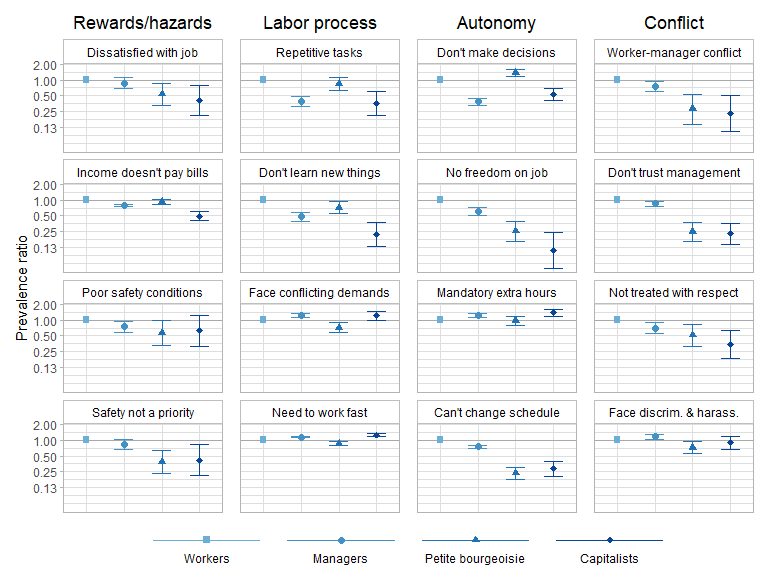

```r
#plot of estimates
(plotted(rows=c(1:12,49:52), xaxis=Class, limitsvec=c(0.049, 1.73), breaksvec=c(0.125, 0.25, 0.5, 1, 2),
        cols=brewer.pal(8, "Blues")[c(5,6,7,8)], shapes=c(15,16,17,18))  +
  plotted(rows=c(13:24,53:56), xaxis=Class, limitsvec=c(0.049, 1.73), breaksvec=c(0.125, 0.25, 0.5, 1, 2),
          cols=brewer.pal(8, "Blues")[c(5,6,7,8)], shapes=c(15,16,17,18)) +
   theme(axis.title.y=element_blank(), axis.text.y=element_blank(), axis.ticks.y=element_blank()) +
  plotted(rows=c(25:36,57:60), xaxis=Class, limitsvec=c(0.049, 1.73), breaksvec=c(0.125, 0.25, 0.5, 1, 2),
          cols=brewer.pal(8, "Blues")[c(5,6,7,8)], shapes=c(15,16,17,18)) +
   theme(axis.title.y=element_blank(), axis.text.y=element_blank(), axis.ticks.y=element_blank()) +
  plotted(rows=c(37:48, 61:64), xaxis=Class, limitsvec=c(0.049, 1.73), breaksvec=c(0.125, 0.25, 0.5, 1, 2),
          cols=brewer.pal(8, "Blues")[c(5,6,7,8)], shapes=c(15,16,17,18)) +
   theme(axis.title.y=element_blank(), axis.text.y=element_blank(), axis.ticks.y=element_blank()) +
  plot_layout(ncol=4)) /
  legends(rows=c(1:3,49), xaxis=Class, cols=brewer.pal(8, "Blues")[c(5,6,7,8)], shapes=c(15,16,17,18), nrow=1) +
  plot_layout(heights=c(1,0.1))
```

```r
#table of estimates
tabled(1:48, "Ref: workers")
```

Ref: workers

| QWL variable | Class | PR | Lower | Upper | Type |
| --- | --- | --- | --- | --- | --- |
| 0.87 | 0.69 | 1.10 | satjob1_bin_unimp | Managers | Rewards/hazards |
| 0.53 | 0.33 | 0.85 | satjob1_bin_unimp | Petite bourgeoisie | Rewards/hazards |
| 0.41 | 0.21 | 0.79 | satjob1_bin_unimp | Capitalists | Rewards/hazards |
| 0.79 | 0.75 | 0.84 | rincblls_bin_unimp | Managers | Rewards/hazards |
| 0.92 | 0.84 | 1.01 | rincblls_bin_unimp | Petite bourgeoisie | Rewards/hazards |
| 0.50 | 0.41 | 0.60 | rincblls_bin_unimp | Capitalists | Rewards/hazards |
| 0.75 | 0.59 | 0.96 | safehlth_bin_unimp | Managers | Rewards/hazards |
| 0.58 | 0.33 | 1.01 | safehlth_bin_unimp | Petite bourgeoisie | Rewards/hazards |
| 0.62 | 0.31 | 1.25 | safehlth_bin_unimp | Capitalists | Rewards/hazards |
| 0.82 | 0.66 | 1.01 | safetywk_bin_unimp | Managers | Rewards/hazards |
| 0.38 | 0.23 | 0.63 | safetywk_bin_unimp | Petite bourgeoisie | Rewards/hazards |
| 0.42 | 0.21 | 0.82 | safetywk_bin_unimp | Capitalists | Rewards/hazards |
| 0.39 | 0.31 | 0.49 | workdiff_bin_unimp | Managers | Labor process |
| 0.84 | 0.64 | 1.11 | workdiff_bin_unimp | Petite bourgeoisie | Labor process |
| 0.36 | 0.21 | 0.61 | workdiff_bin_unimp | Capitalists | Labor process |
| 0.48 | 0.40 | 0.59 | learnnew_bin_unimp | Managers | Labor process |
| 0.72 | 0.57 | 0.93 | learnnew_bin_unimp | Petite bourgeoisie | Labor process |
| 0.22 | 0.13 | 0.38 | learnnew_bin_unimp | Capitalists | Labor process |
| 1.23 | 1.12 | 1.36 | condemnd_bin_unimp | Managers | Labor process |
| 0.72 | 0.57 | 0.91 | condemnd_bin_unimp | Petite bourgeoisie | Labor process |
| 1.21 | 1.00 | 1.46 | condemnd_bin_unimp | Capitalists | Labor process |
| 1.15 | 1.11 | 1.20 | workfast_bin_unimp | Managers | Labor process |
| 0.86 | 0.78 | 0.95 | workfast_bin_unimp | Petite bourgeoisie | Labor process |
| 1.26 | 1.17 | 1.34 | workfast_bin_unimp | Capitalists | Labor process |
| 0.39 | 0.33 | 0.45 | wkdecide_bin_unimp | Managers | Autonomy |
| 1.37 | 1.19 | 1.58 | wkdecide_bin_unimp | Petite bourgeoisie | Autonomy |
| 0.53 | 0.41 | 0.69 | wkdecide_bin_unimp | Capitalists | Autonomy |
| 0.60 | 0.50 | 0.72 | wkfreedm_bin_unimp | Managers | Autonomy |
| 0.25 | 0.16 | 0.40 | wkfreedm_bin_unimp | Petite bourgeoisie | Autonomy |
| 0.11 | 0.05 | 0.24 | wkfreedm_bin_unimp | Capitalists | Autonomy |
| 1.21 | 1.10 | 1.34 | mustwork_bin_unimp | Managers | Autonomy |
| 0.96 | 0.79 | 1.17 | mustwork_bin_unimp | Petite bourgeoisie | Autonomy |
| 1.37 | 1.18 | 1.60 | mustwork_bin_unimp | Capitalists | Autonomy |
| 0.75 | 0.69 | 0.81 | chngtme_bin_unimp | Managers | Autonomy |
| 0.23 | 0.18 | 0.30 | chngtme_bin_unimp | Petite bourgeoisie | Autonomy |
| 0.28 | 0.21 | 0.39 | chngtme_bin_unimp | Capitalists | Autonomy |
| 0.76 | 0.61 | 0.95 | manvsemp_bin_unimp | Managers | Conflict |
| 0.28 | 0.14 | 0.54 | manvsemp_bin_unimp | Petite bourgeoisie | Conflict |
| 0.23 | 0.10 | 0.50 | manvsemp_bin_unimp | Capitalists | Conflict |
| 0.84 | 0.75 | 0.95 | trustman_bin_unimp | Managers | Conflict |
| 0.24 | 0.16 | 0.37 | trustman_bin_unimp | Petite bourgeoisie | Conflict |
| 0.23 | 0.14 | 0.36 | trustman_bin_unimp | Capitalists | Conflict |
| 0.70 | 0.55 | 0.90 | respect_bin_unimp | Managers | Conflict |
| 0.51 | 0.32 | 0.82 | respect_bin_unimp | Petite bourgeoisie | Conflict |
| 0.34 | 0.18 | 0.64 | respect_bin_unimp | Capitalists | Conflict |
| 1.17 | 1.04 | 1.31 | disc_haras_bin_unimp | Managers | Conflict |
| 0.72 | 0.56 | 0.93 | disc_haras_bin_unimp | Petite bourgeoisie | Conflict |
| 0.89 | 0.68 | 1.16 | disc_haras_bin_unimp | Capitalists | Conflict |

## Gender, race, and select QWL variables among workers

Prevalence of bad category of each binary QWL variable among each minoritized gender, racial, or gender-racial group of workers relative to the prevalence among male, white, or white male workers adjusted for age and year with restricted cubic splines.

### Gender

```r
#run regression
less_adj <- mysvy(subset(svy_dat_mi, class=="Workers"), c(33:48), "~relevel(as.factor(sex), ref='male') + rcs(age, 3) + rcs(year, 3)")

#pull into matrix
regs_less <- matrix_func(16, 3, c(33:48))

#for some reason function doesn't work properly when only extract one coefficient so we need to delete every other row from regs_less to get df formatted correctly
nth.delete <- function(dataframe, n)dataframe[-(seq(n,to=nrow(dataframe),by=n)),]
regs_less <- nth.delete(regs_less, 2)

#format matrix
binded <- formatted(c("Female"), 16,
                    c("satjob1_bin_unimp", "rincblls_bin_unimp", "safehlth_bin_unimp", "safetywk_bin_unimp",
                      "workdiff_bin_unimp", "learnnew_bin_unimp", "condemnd_bin_unimp", "workfast_bin_unimp",
                      "wkdecide_bin_unimp", "wkfreedm_bin_unimp", "mustwork_bin_unimp", "chngtme_bin_unimp",
                      "manvsemp_bin_unimp", "trustman_bin_unimp", "respect_bin_unimp", "disc_haras_bin_unimp"),
                    "Male",
                    c("Male", "Female"))
```

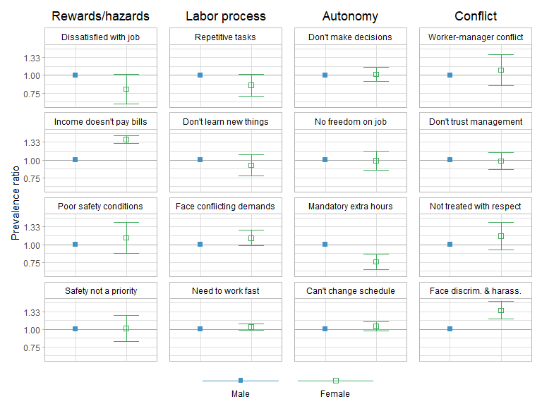

```r
#plot of estimates
(plotted(rows=c(1:4,17:20), xaxis=Class, limitsvec=c(0.62,1.57), breaksvec=c(0.75, 1, 1.3333333, 1.333333^2),
        cols=c(brewer.pal(8, "Blues")[c(6)], brewer.pal(8, "Greens")[c(6)]), shapes=c(15, 0))  +
  plotted(rows=c(5:8,21:24), xaxis=Class, limitsvec=c(0.62,1.57), breaksvec=c(0.75, 1, 1.3333333, 1.333333^2),
          cols=c(brewer.pal(8, "Blues")[c(6)], brewer.pal(8, "Greens")[c(6)]), shapes=c(15, 0)) +
   theme(axis.title.y=element_blank(), axis.text.y=element_blank(), axis.ticks.y=element_blank()) +
  plotted(rows=c(9:12,25:28), xaxis=Class, limitsvec=c(0.62,1.57), breaksvec=c(0.75, 1, 1.3333333, 1.333333^2),
          cols=c(brewer.pal(8, "Blues")[c(6)], brewer.pal(8, "Greens")[c(6)]), shapes=c(15, 0)) +
   theme(axis.title.y=element_blank(), axis.text.y=element_blank(), axis.ticks.y=element_blank()) +
  plotted(rows=c(13:16,29:32), xaxis=Class, limitsvec=c(0.62,1.57), breaksvec=c(0.75, 1, 1.3333333, 1.333333^2),
          cols=c(brewer.pal(8, "Blues")[c(6)], brewer.pal(8, "Greens")[c(6)]), shapes=c(15, 0)) +
   theme(axis.title.y=element_blank(), axis.text.y=element_blank(), axis.ticks.y=element_blank()) +
  plot_layout(ncol=4)) /
  legends(rows=c(1,17), xaxis=Class, cols=c(brewer.pal(8, "Blues")[c(6)], brewer.pal(8, "Greens")[c(6)]), shapes=c(15, 0), nrow=1) +
  plot_layout(heights=c(1,0.1))
```

```r
#table of estimates
tabled(1:16, "Ref: male")
```

Ref: male

| QWL variable | Class | PR | Lower | Upper | Type |
| --- | --- | --- | --- | --- | --- |
| 0.80 | 0.63 | 1.02 | satjob1_bin_unimp | Female | Rewards/hazards |
| 1.40 | 1.31 | 1.49 | rincblls_bin_unimp | Female | Rewards/hazards |
| 1.12 | 0.87 | 1.44 | safehlth_bin_unimp | Female | Rewards/hazards |
| 1.01 | 0.82 | 1.26 | safetywk_bin_unimp | Female | Rewards/hazards |
| 0.85 | 0.71 | 1.02 | workdiff_bin_unimp | Female | Labor process |
| 0.92 | 0.77 | 1.09 | learnnew_bin_unimp | Female | Labor process |
| 1.11 | 0.98 | 1.26 | condemnd_bin_unimp | Female | Labor process |
| 1.04 | 0.98 | 1.09 | workfast_bin_unimp | Female | Labor process |
| 1.02 | 0.91 | 1.14 | wkdecide_bin_unimp | Female | Autonomy |
| 0.99 | 0.85 | 1.16 | wkfreedm_bin_unimp | Female | Autonomy |
| 0.75 | 0.66 | 0.86 | mustwork_bin_unimp | Female | Autonomy |
| 1.05 | 0.97 | 1.13 | chngtme_bin_unimp | Female | Autonomy |
| 1.09 | 0.85 | 1.40 | manvsemp_bin_unimp | Female | Conflict |
| 0.98 | 0.86 | 1.12 | trustman_bin_unimp | Female | Conflict |
| 1.14 | 0.92 | 1.43 | respect_bin_unimp | Female | Conflict |
| 1.36 | 1.18 | 1.57 | disc_haras_bin_unimp | Female | Conflict |

### Race

```r
#run regression
less_adj <- mysvy(subset(svy_dat_mi, class=="Workers"), c(33:48), "~race_h + rcs(age, 3) + rcs(year, 3)")

#pull into matrix
regs_less <- matrix_func(16, 4, 33:48)

#format matrix
binded <- formatted(c("NH Black", "NH other", "Hispanic"), 16,
                    c("satjob1_bin_unimp", "rincblls_bin_unimp", "safehlth_bin_unimp", "safetywk_bin_unimp",
                      "workdiff_bin_unimp", "learnnew_bin_unimp", "condemnd_bin_unimp", "workfast_bin_unimp",
                      "wkdecide_bin_unimp", "wkfreedm_bin_unimp", "mustwork_bin_unimp", "chngtme_bin_unimp",
                      "manvsemp_bin_unimp", "trustman_bin_unimp", "respect_bin_unimp", "disc_haras_bin_unimp"),
                    "NH white",
                    c("NH white", "NH Black", "NH other", "Hispanic"))
```

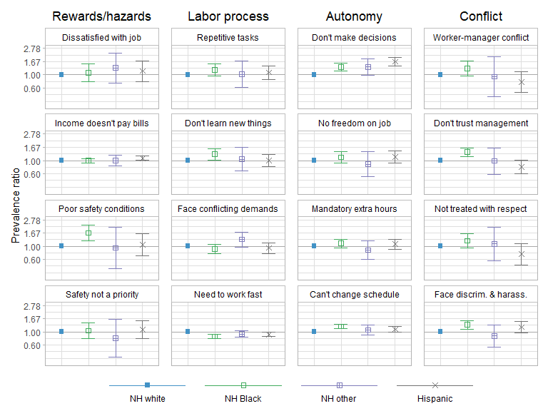

```r
#plot of estimates
(plotted(rows=c(1:12,49:52), xaxis=Class, limitsvec=c(0.30, 2.80), breaksvec=c(0.6, 1, 1.666667, 1.666667^2),
        cols=c(brewer.pal(8, "Blues")[c(6)], brewer.pal(8, "Greens")[c(6)], brewer.pal(8, "Purples")[c(6)], brewer.pal(8, "Greys")[c(6)]), shapes=c(15, 0, 12, 4))  +
  plotted(rows=c(13:24,53:56), xaxis=Class, limitsvec=c(0.30, 2.80), breaksvec=c(0.6, 1, 1.666667, 1.666667^2),
          cols=c(brewer.pal(8, "Blues")[c(6)], brewer.pal(8, "Greens")[c(6)], brewer.pal(8, "Purples")[c(6)], brewer.pal(8, "Greys")[c(6)]), shapes=c(15, 0, 12, 4))  +
    theme(axis.title.y=element_blank(), axis.text.y=element_blank(), axis.ticks.y=element_blank()) +
  plotted(rows=c(25:36,57:60), xaxis=Class, limitsvec=c(0.30, 2.80), breaksvec=c(0.6, 1, 1.666667, 1.666667^2),
          cols=c(brewer.pal(8, "Blues")[c(6)], brewer.pal(8, "Greens")[c(6)], brewer.pal(8, "Purples")[c(6)], brewer.pal(8, "Greys")[c(6)]), shapes=c(15, 0, 12, 4))  +
    theme(axis.title.y=element_blank(), axis.text.y=element_blank(), axis.ticks.y=element_blank()) +
  plotted(rows=c(37:48,61:64), xaxis=Class, limitsvec=c(0.30, 2.80), breaksvec=c(0.6, 1, 1.666667, 1.666667^2),
          cols=c(brewer.pal(8, "Blues")[c(6)], brewer.pal(8, "Greens")[c(6)], brewer.pal(8, "Purples")[c(6)], brewer.pal(8, "Greys")[c(6)]), shapes=c(15, 0, 12, 4))  +
    theme(axis.title.y=element_blank(), axis.text.y=element_blank(), axis.ticks.y=element_blank()) +
  plot_layout(ncol=4)) /
  legends(rows=c(1:3,49), xaxis=Class, cols=c(brewer.pal(8, "Blues")[c(6)], brewer.pal(8, "Greens")[c(6)], brewer.pal(8, "Purples")[c(6)], brewer.pal(8, "Greys")[c(6)]),
          shapes=c(15, 0, 12, 4), nrow=1) +
  plot_layout(heights=c(1,0.1))
```

```r
#table of estimates
tabled(1:48, "Ref: white")
```

Ref: white

| QWL variable | Class | PR | Lower | Upper | Type |
| --- | --- | --- | --- | --- | --- |
| 1.09 | 0.78 | 1.52 | satjob1_bin_unimp | NH Black | Rewards/hazards |
| 1.31 | 0.73 | 2.33 | satjob1_bin_unimp | NH other | Rewards/hazards |
| 1.16 | 0.78 | 1.73 | satjob1_bin_unimp | Hispanic | Rewards/hazards |
| 0.99 | 0.91 | 1.09 | rincblls_bin_unimp | NH Black | Rewards/hazards |
| 1.00 | 0.81 | 1.22 | rincblls_bin_unimp | NH other | Rewards/hazards |
| 1.09 | 1.01 | 1.18 | rincblls_bin_unimp | Hispanic | Rewards/hazards |
| 1.67 | 1.25 | 2.25 | safehlth_bin_unimp | NH Black | Rewards/hazards |
| 0.94 | 0.42 | 2.10 | safehlth_bin_unimp | NH other | Rewards/hazards |
| 1.05 | 0.69 | 1.61 | safehlth_bin_unimp | Hispanic | Rewards/hazards |
| 1.05 | 0.78 | 1.40 | safetywk_bin_unimp | NH Black | Rewards/hazards |
| 0.78 | 0.38 | 1.61 | safetywk_bin_unimp | NH other | Rewards/hazards |
| 1.10 | 0.77 | 1.56 | safetywk_bin_unimp | Hispanic | Rewards/hazards |
| 1.21 | 0.97 | 1.52 | workdiff_bin_unimp | NH Black | Labor process |
| 1.02 | 0.62 | 1.70 | workdiff_bin_unimp | NH other | Labor process |
| 1.10 | 0.84 | 1.43 | workdiff_bin_unimp | Hispanic | Labor process |
| 1.27 | 1.02 | 1.59 | learnnew_bin_unimp | NH Black | Labor process |
| 1.05 | 0.66 | 1.66 | learnnew_bin_unimp | NH other | Labor process |
| 1.00 | 0.79 | 1.26 | learnnew_bin_unimp | Hispanic | Labor process |
| 0.90 | 0.76 | 1.08 | condemnd_bin_unimp | NH Black | Labor process |
| 1.30 | 0.97 | 1.73 | condemnd_bin_unimp | NH other | Labor process |
| 0.93 | 0.76 | 1.15 | condemnd_bin_unimp | Hispanic | Labor process |
| 0.84 | 0.77 | 0.91 | workfast_bin_unimp | NH Black | Labor process |
| 0.92 | 0.81 | 1.05 | workfast_bin_unimp | NH other | Labor process |
| 0.91 | 0.83 | 0.98 | workfast_bin_unimp | Hispanic | Labor process |
| 1.35 | 1.15 | 1.59 | wkdecide_bin_unimp | NH Black | Autonomy |
| 1.36 | 1.00 | 1.87 | wkdecide_bin_unimp | NH other | Autonomy |
| 1.66 | 1.41 | 1.95 | wkdecide_bin_unimp | Hispanic | Autonomy |
| 1.13 | 0.91 | 1.40 | wkfreedm_bin_unimp | NH Black | Autonomy |
| 0.87 | 0.53 | 1.42 | wkfreedm_bin_unimp | NH other | Autonomy |
| 1.14 | 0.90 | 1.45 | wkfreedm_bin_unimp | Hispanic | Autonomy |
| 1.11 | 0.94 | 1.31 | mustwork_bin_unimp | NH Black | Autonomy |
| 0.87 | 0.60 | 1.25 | mustwork_bin_unimp | NH other | Autonomy |
| 1.09 | 0.89 | 1.32 | mustwork_bin_unimp | Hispanic | Autonomy |
| 1.24 | 1.13 | 1.36 | chngtme_bin_unimp | NH Black | Autonomy |
| 1.08 | 0.88 | 1.32 | chngtme_bin_unimp | NH other | Autonomy |
| 1.10 | 0.99 | 1.24 | chngtme_bin_unimp | Hispanic | Autonomy |
| 1.28 | 0.96 | 1.71 | manvsemp_bin_unimp | NH Black | Conflict |
| 0.93 | 0.43 | 2.04 | manvsemp_bin_unimp | NH other | Conflict |
| 0.76 | 0.51 | 1.13 | manvsemp_bin_unimp | Hispanic | Conflict |
| 1.38 | 1.18 | 1.63 | trustman_bin_unimp | NH Black | Conflict |
| 0.98 | 0.59 | 1.64 | trustman_bin_unimp | NH other | Conflict |
| 0.78 | 0.61 | 1.01 | trustman_bin_unimp | Hispanic | Conflict |
| 1.23 | 0.94 | 1.62 | respect_bin_unimp | NH Black | Conflict |
| 1.09 | 0.57 | 2.08 | respect_bin_unimp | NH other | Conflict |
| 0.74 | 0.49 | 1.11 | respect_bin_unimp | Hispanic | Conflict |
| 1.31 | 1.11 | 1.54 | disc_haras_bin_unimp | NH Black | Conflict |
| 0.85 | 0.55 | 1.32 | disc_haras_bin_unimp | NH other | Conflict |
| 1.20 | 0.96 | 1.49 | disc_haras_bin_unimp | Hispanic | Conflict |

### Gender-race interaction

```r
#run regression
less_adj <- mysvy(subset(svy_dat_mi, class=="Workers"), 33:48, "~race_h_gender + rcs(age, 3) + rcs(year, 3)")

#pull into matrix
regs_less <- matrix_func(16, 8, 33:48)

#format matrix
binded <- formatted(c("NH white women", "NH Black men", "NH Black women", "NH other men", "NH other women", "Hispanic men", "Hispanic women"), 16,
                    c("satjob1_bin_unimp", "rincblls_bin_unimp", "safehlth_bin_unimp", "safetywk_bin_unimp",
                      "workdiff_bin_unimp", "learnnew_bin_unimp", "condemnd_bin_unimp", "workfast_bin_unimp",
                      "wkdecide_bin_unimp", "wkfreedm_bin_unimp", "mustwork_bin_unimp", "chngtme_bin_unimp",
                      "manvsemp_bin_unimp", "trustman_bin_unimp", "respect_bin_unimp", "disc_haras_bin_unimp"),
                    "NH white men",
                    c("NH white men" , "NH white women", "NH Black men", "NH Black women", "NH other men", "NH other women", "Hispanic men", "Hispanic women"))
```

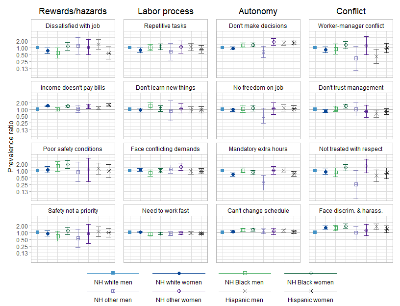

```r
#plot estimates
(plotted(rows=c(1:28,113:116), xaxis=Class, limitsvec=c(0.06, 4.35), breaksvec=c(0.125, 0.25, 0.5, 1, 2),
        cols=c(brewer.pal(8, "Blues")[c(6,8)], brewer.pal(8, "Greens")[c(6,8)], brewer.pal(8, "Purples")[c(6,8)], brewer.pal(8, "Greys")[c(6,8)]), shapes=c(15, 16, 0, 1, 12, 10, 4, 8))  +
  plotted(rows=c(29:56,117:120), xaxis=Class, limitsvec=c(0.06, 4.35), breaksvec=c(0.125, 0.25, 0.5, 1, 2),
        cols=c(brewer.pal(8, "Blues")[c(6,8)], brewer.pal(8, "Greens")[c(6,8)], brewer.pal(8, "Purples")[c(6,8)], brewer.pal(8, "Greys")[c(6,8)]), shapes=c(15, 16, 0, 1, 12, 10, 4, 8))  +
    theme(axis.title.y=element_blank(), axis.text.y=element_blank(), axis.ticks.y=element_blank()) +
  plotted(rows=c(57:84,121:124), xaxis=Class, limitsvec=c(0.06, 4.35), breaksvec=c(0.125, 0.25, 0.5, 1, 2),
        cols=c(brewer.pal(8, "Blues")[c(6,8)], brewer.pal(8, "Greens")[c(6,8)], brewer.pal(8, "Purples")[c(6,8)], brewer.pal(8, "Greys")[c(6,8)]), shapes=c(15, 16, 0, 1, 12, 10, 4, 8))  +
    theme(axis.title.y=element_blank(), axis.text.y=element_blank(), axis.ticks.y=element_blank()) +
  plotted(rows=c(85:112,125:128), xaxis=Class, limitsvec=c(0.06, 4.35), breaksvec=c(0.125, 0.25, 0.5, 1, 2),
        cols=c(brewer.pal(8, "Blues")[c(6,8)], brewer.pal(8, "Greens")[c(6,8)], brewer.pal(8, "Purples")[c(6,8)], brewer.pal(8, "Greys")[c(6,8)]), shapes=c(15, 16, 0, 1, 12, 10, 4, 8))  +
    theme(axis.title.y=element_blank(), axis.text.y=element_blank(), axis.ticks.y=element_blank()) +
  plot_layout(ncol=4)) /
  legends(rows=c(1:7,113), xaxis=Class, cols=c(brewer.pal(8, "Blues")[c(6,8)], brewer.pal(8, "Greens")[c(6,8)], brewer.pal(8, "Purples")[c(6,8)], brewer.pal(8, "Greys")[c(6,8)]),
          shapes=c(15, 16, 0, 1, 12, 10, 4, 8), nrow=2) +
  plot_layout(heights=c(1,0.15))
```

```r
#table of estimates
tabled(1:128, "Ref: white male")
```

Ref: white male

| QWL variable | Class | PR | Lower | Upper | Type |
| --- | --- | --- | --- | --- | --- |
| 0.75 | 0.56 | 1.01 | satjob1_bin_unimp | NH white women | Rewards/hazards |
| 0.59 | 0.34 | 1.02 | satjob1_bin_unimp | NH Black men | Rewards/hazards |
| 1.18 | 0.80 | 1.74 | satjob1_bin_unimp | NH Black women | Rewards/hazards |
| 1.22 | 0.53 | 2.79 | satjob1_bin_unimp | NH other men | Rewards/hazards |
| 1.07 | 0.48 | 2.35 | satjob1_bin_unimp | NH other women | Rewards/hazards |
| 1.42 | 0.88 | 2.29 | satjob1_bin_unimp | Hispanic men | Rewards/hazards |
| 0.58 | 0.31 | 1.08 | satjob1_bin_unimp | Hispanic women | Rewards/hazards |
| 1.43 | 1.31 | 1.55 | rincblls_bin_unimp | NH white women | Rewards/hazards |
| 0.99 | 0.84 | 1.18 | rincblls_bin_unimp | NH Black men | Rewards/hazards |
| 1.38 | 1.24 | 1.55 | rincblls_bin_unimp | NH Black women | Rewards/hazards |
| 1.05 | 0.74 | 1.50 | rincblls_bin_unimp | NH other men | Rewards/hazards |
| 1.36 | 1.09 | 1.69 | rincblls_bin_unimp | NH other women | Rewards/hazards |
| 1.15 | 0.99 | 1.33 | rincblls_bin_unimp | Hispanic men | Rewards/hazards |
| 1.55 | 1.39 | 1.73 | rincblls_bin_unimp | Hispanic women | Rewards/hazards |
| 1.13 | 0.81 | 1.58 | safehlth_bin_unimp | NH white women | Rewards/hazards |
| 1.59 | 0.96 | 2.62 | safehlth_bin_unimp | NH Black men | Rewards/hazards |
| 1.93 | 1.32 | 2.82 | safehlth_bin_unimp | NH Black women | Rewards/hazards |
| 0.90 | 0.33 | 2.44 | safehlth_bin_unimp | NH other men | Rewards/hazards |
| 1.09 | 0.33 | 3.61 | safehlth_bin_unimp | NH other women | Rewards/hazards |
| 1.27 | 0.71 | 2.26 | safehlth_bin_unimp | Hispanic men | Rewards/hazards |
| 0.99 | 0.50 | 1.96 | safehlth_bin_unimp | Hispanic women | Rewards/hazards |
| 0.90 | 0.69 | 1.19 | safetywk_bin_unimp | NH white women | Rewards/hazards |
| 0.69 | 0.42 | 1.12 | safetywk_bin_unimp | NH Black men | Rewards/hazards |
| 1.20 | 0.83 | 1.73 | safetywk_bin_unimp | NH Black women | Rewards/hazards |
| 0.55 | 0.22 | 1.41 | safetywk_bin_unimp | NH other men | Rewards/hazards |
| 0.88 | 0.33 | 2.31 | safetywk_bin_unimp | NH other women | Rewards/hazards |
| 1.08 | 0.66 | 1.79 | safetywk_bin_unimp | Hispanic men | Rewards/hazards |
| 0.99 | 0.63 | 1.58 | safetywk_bin_unimp | Hispanic women | Rewards/hazards |
| 0.78 | 0.61 | 0.99 | workdiff_bin_unimp | NH white women | Labor process |
| 1.03 | 0.74 | 1.43 | workdiff_bin_unimp | NH Black men | Labor process |

[output cut: 98 more lines]

# Appendix

## How many employees do PBs and capitalists typically identify as having?

Note that the numemps variable wasn’t asked in 2002, which is why we aren’t using it for our primary analyses. Note also that numemps was only asked of people who identified as self-employed, which further supports our use of the self-employed variable to identify owners.

```r
#run on unimputed data
dat %>%
  filter(year !=2002 & c(class=="Capitalists" | class=="Petit bourgeoisie")) %>%
  group_by(class) %>%
  summarise(mean_emps=round(mean(as.numeric(numemps), na.rm=T),1),
            median_emps=round(median(as.numeric(numemps), na.rm=T),1),
            lower_IQR=round(quantile(as.numeric(numemps), 0.25, na.rm=T),1),
            upper_IQR=round(quantile(as.numeric(numemps), 0.75, na.rm=T),1),
            max=max(as.numeric(numemps), na.rm=T)) %>%
  kable() %>%
  kable_styling("striped") %>%
  scroll_box(width = "100%", height = "250px")
```

| class | mean_emps | median_emps | lower_IQR | upper_IQR | max |
| --- | --- | --- | --- | --- | --- |
| Petit bourgeoisie | 0.2 | 0 | 0 | 0 | 34 |
| Capitalists | 6.0 | 2 | 0 | 6 | 97 |

## Imputation convergence plots

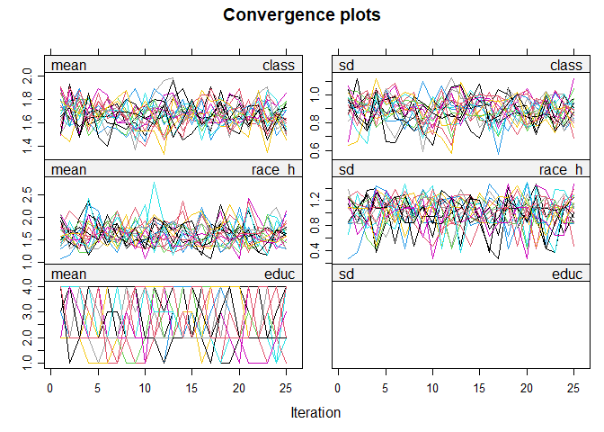

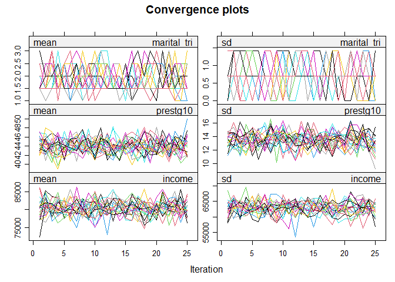

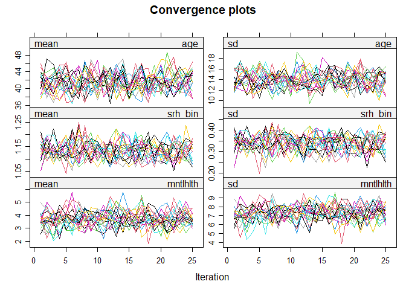

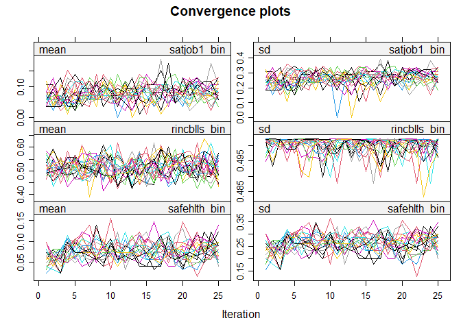

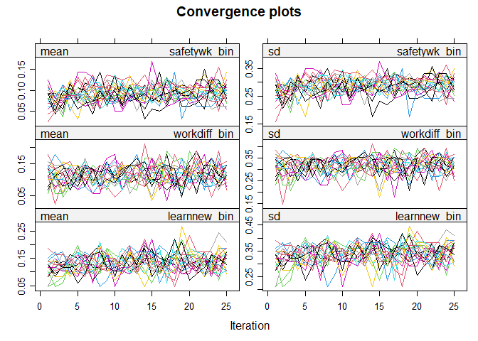

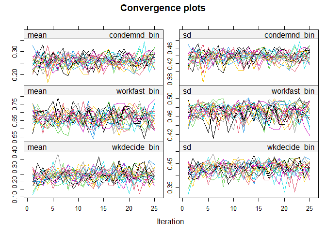

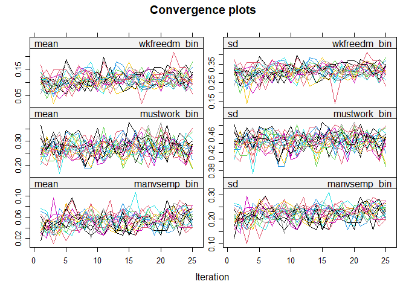

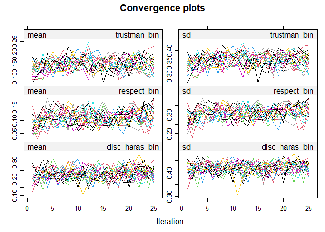

```r
plot(imp_merged, y=c('class', 'race_h', 'educ', 'marital_tri', "prestg10", 'income', 'age', "srh_bin", "mntlhlth", "satjob1_bin", "rincblls_bin", "safehlth_bin", "safetywk_bin", "workdiff_bin", "learnnew_bin", "condemnd_bin", "workfast_bin", "wkdecide_bin", "wkfreedm_bin", "mustwork_bin", "manvsemp_bin", "trustman_bin", "respect_bin", "disc_haras_bin"), main='Convergence plots')
```